# Charlotte Apartments Descriptive Statistics

Apartments are everywhere in Charlotte, rising with the skyline and filling in the gaps between breweries, greenways, and office towers. Whether you’re renting in a sleek Uptown high-rise or a quiet suburban complex, you’ve probably noticed one thing: prices vary wildly. So do layouts, square footage, and amenities. What’s driving those differences, and what do they say about how Charlotte lives?

In this multi-part analysis, we’ll explore the numbers behind the city’s rental housing market. We’ll look at how rent scales with bedroom count, which neighborhoods offer the most space for your dollar, and how amenities factor into pricing. From descriptive stats to predictive modeling, Aptly Charlotte turns raw apartment data into real-world insights.

The dataset we’re working with includes hundreds of apartment listings across Charlotte, grouped by bedroom count, complex, and neighborhood. With this data, we can uncover patterns in unit design, pricing efficiency, and market segmentation. The goal is to help renters, investors, and analysts understand what makes one apartment worth more than another.

Let’s dig into the trends, break down the distribution, and see what Charlotte’s rental market is really made of.

# Data Loading and Cleaning

```python
########>>  INTITIALIZE  <<########
#basic operation libraries
import os
import sys
import ast
import datetime
import re
import time

#data analysis libraries
import pandas as pd
import numpy as np
import seaborn as sns
import matplotlib.pyplot as plt
%matplotlib inline

#mathematical libraries
import math

#geospacial libraries
from geopy.geocoders import Nominatim
from geopy.distance import geodesic

#display settings for Jupyter display, feel free to edit
from IPython.display import display, HTML

#display settings for Pandas, feel free to edit
pd.set_option('display.html.table_schema', True)
pd.set_option('expand_frame_repr', True)
pd.set_option('display.max_colwidth', 200)
pd.options.display.html.use_mathjax = False

#manage warnings
import warnings
warnings.filterwarnings('ignore')

# using the following script allows me to 'know' when my block of code has completed
print ("\n" + '{:<5} : {:2}'.format("Finished", str(datetime.datetime.now())))
```

```
Finished : 2025-10-09 21:20:08.314505
```

```python
apt = pd.read_csv(r"C:\Users\alexp\Downloads\Charlotte Apartments.csv")

apt
```

|  | Complex | Address | Unit_Variant | Bedrooms | Bathrooms | Rent | Sqft | Amenities | Website |
| --- | --- | --- | --- | --- | --- | --- | --- | --- | --- |
| 0 | Moderna Liberty Row | 7740 Liberty Row Dr, Charlotte, NC 28210 | S01 | Studio | 1.0 | 1469.0 | 651.0 | In-unit washer/dryer; High-speed internet in common areas; Controlled access bicycle storage; Additional storage available; Resort-style pool; 24-hour fitness center; Game room with billiards, pok... | https://www.moderalibertyrow.com/ |
| 1 | Moderna Liberty Row | 7740 Liberty Row Dr, Charlotte, NC 28210 | A01 | 1 | 1.0 | NaN | 747.0 | In-unit washer/dryer; High-speed internet in common areas; Controlled access bicycle storage; Additional storage available; Resort-style pool; 24-hour fitness center; Game room with billiards, pok... | https://www.moderalibertyrow.com/ |
| 2 | Moderna Liberty Row | 7740 Liberty Row Dr, Charlotte, NC 28210 | A02 | 1 | 1.0 | NaN | 747.0 | In-unit washer/dryer; High-speed internet in common areas; Controlled access bicycle storage; Additional storage available; Resort-style pool; 24-hour fitness center; Game room with billiards, pok... | https://www.moderalibertyrow.com/ |
| 3 | Moderna Liberty Row | 7740 Liberty Row Dr, Charlotte, NC 28210 | A03 | 1 | 1.0 | 1532.0 | 801.0 | In-unit washer/dryer; High-speed internet in common areas; Controlled access bicycle storage; Additional storage available; Resort-style pool; 24-hour fitness center; Game room with billiards, pok... | https://www.moderalibertyrow.com/ |
| 4 | Moderna Liberty Row | 7740 Liberty Row Dr, Charlotte, NC 28210 | A04 | 1 | 1.0 | 1766.0 | 861.0 | In-unit washer/dryer; High-speed internet in common areas; Controlled access bicycle storage; Additional storage available; Resort-style pool; 24-hour fitness center; Game room with billiards, pok... | https://www.moderalibertyrow.com/ |
| ... | ... | ... | ... | ... | ... | ... | ... | ... | ... |
| 251 | Broadstone Craft | 1015 N Alexander Street, Charlotte, NC 28206 | B3 | 2 | 2.0 | 2009.0 | 1069.0 | In-unit washer/dryer; High-speed internet in common areas; EV charging stations; Resort-style pool; 24-hour fitness center; Sophisticated lounges; Bespoke services; Controlled-access security; Dog... | https://broadstonecraft.com/ |
| 252 | Broadstone Craft | 1015 N Alexander Street, Charlotte, NC 28206 | B4 | 2 | 2.0 | 2315.0 | 1113.0 | In-unit washer/dryer; High-speed internet in common areas; EV charging stations; Resort-style pool; 24-hour fitness center; Sophisticated lounges; Bespoke services; Controlled-access security; Dog... | https://broadstonecraft.com/ |
| 253 | Broadstone Craft | 1015 N Alexander Street, Charlotte, NC 28206 | B5 | 2 | 2.0 | 2150.0 | 1149.0 | In-unit washer/dryer; High-speed internet in common areas; EV charging stations; Resort-style pool; 24-hour fitness center; Sophisticated lounges; Bespoke services; Controlled-access security; Dog... | https://broadstonecraft.com/ |
| 254 | Broadstone Craft | 1015 N Alexander Street, Charlotte, NC 28206 | B6 | 2 | 2.0 | 2572.0 | 1208.0 | In-unit washer/dryer; High-speed internet in common areas; EV charging stations; Resort-style pool; 24-hour fitness center; Sophisticated lounges; Bespoke services; Controlled-access security; Dog... | https://broadstonecraft.com/ |
| 255 | Broadstone Craft | 1015 N Alexander Street, Charlotte, NC 28206 | B7 | 2 | 2.0 | 2714.0 | 1240.0 | In-unit washer/dryer; High-speed internet in common areas; EV charging stations; Resort-style pool; 24-hour fitness center; Sophisticated lounges; Bespoke services; Controlled-access security; Dog... | https://broadstonecraft.com/ |

256 rows × 9 columns

To capture a representative snapshot of Charlotte’s rental landscape, apartment complexes were selected based on diversity in size, pricing, and geographic location. The sample includes both modern developments and established communities across a range of neighborhoods, ensuring coverage of premium urban properties and more residential suburban options.

Listings were sourced primarily from online platforms, with each complex required to have complete and consistent data. This included square footage, bedroom count, and monthly rent, allowing for standardized comparisons across units and properties.

The selection strategy prioritized variation. By including complexes with different design profiles and market positioning, the dataset supports meaningful analysis of how living space, pricing, and perceived value shift across Charlotte’s segmented housing market. This foundation enables deeper insights into spatial trends, unit-level efficiency, and pricing logic across the city.

```python
print(apt.dtypes)
```

```
Complex          object
Address          object
Unit_Variant     object
Bedrooms         object
Bathrooms       float64
Rent            float64
Sqft            float64
Amenities        object
Website          object
dtype: object
```

```python
apt['Bedrooms'] = apt['Bedrooms'].replace('Studio', 0)
apt['Bedrooms'] = pd.to_numeric(apt['Bedrooms'], errors='coerce').astype('Int64')

apt
```

|  | Complex | Address | Unit_Variant | Bedrooms | Bathrooms | Rent | Sqft | Amenities | Website |
| --- | --- | --- | --- | --- | --- | --- | --- | --- | --- |
| 0 | Moderna Liberty Row | 7740 Liberty Row Dr, Charlotte, NC 28210 | S01 | 0 | 1.0 | 1469.0 | 651.0 | In-unit washer/dryer; High-speed internet in common areas; Controlled access bicycle storage; Additional storage available; Resort-style pool; 24-hour fitness center; Game room with billiards, pok... | https://www.moderalibertyrow.com/ |
| 1 | Moderna Liberty Row | 7740 Liberty Row Dr, Charlotte, NC 28210 | A01 | 1 | 1.0 | NaN | 747.0 | In-unit washer/dryer; High-speed internet in common areas; Controlled access bicycle storage; Additional storage available; Resort-style pool; 24-hour fitness center; Game room with billiards, pok... | https://www.moderalibertyrow.com/ |
| 2 | Moderna Liberty Row | 7740 Liberty Row Dr, Charlotte, NC 28210 | A02 | 1 | 1.0 | NaN | 747.0 | In-unit washer/dryer; High-speed internet in common areas; Controlled access bicycle storage; Additional storage available; Resort-style pool; 24-hour fitness center; Game room with billiards, pok... | https://www.moderalibertyrow.com/ |
| 3 | Moderna Liberty Row | 7740 Liberty Row Dr, Charlotte, NC 28210 | A03 | 1 | 1.0 | 1532.0 | 801.0 | In-unit washer/dryer; High-speed internet in common areas; Controlled access bicycle storage; Additional storage available; Resort-style pool; 24-hour fitness center; Game room with billiards, pok... | https://www.moderalibertyrow.com/ |
| 4 | Moderna Liberty Row | 7740 Liberty Row Dr, Charlotte, NC 28210 | A04 | 1 | 1.0 | 1766.0 | 861.0 | In-unit washer/dryer; High-speed internet in common areas; Controlled access bicycle storage; Additional storage available; Resort-style pool; 24-hour fitness center; Game room with billiards, pok... | https://www.moderalibertyrow.com/ |
| ... | ... | ... | ... | ... | ... | ... | ... | ... | ... |
| 251 | Broadstone Craft | 1015 N Alexander Street, Charlotte, NC 28206 | B3 | 2 | 2.0 | 2009.0 | 1069.0 | In-unit washer/dryer; High-speed internet in common areas; EV charging stations; Resort-style pool; 24-hour fitness center; Sophisticated lounges; Bespoke services; Controlled-access security; Dog... | https://broadstonecraft.com/ |
| 252 | Broadstone Craft | 1015 N Alexander Street, Charlotte, NC 28206 | B4 | 2 | 2.0 | 2315.0 | 1113.0 | In-unit washer/dryer; High-speed internet in common areas; EV charging stations; Resort-style pool; 24-hour fitness center; Sophisticated lounges; Bespoke services; Controlled-access security; Dog... | https://broadstonecraft.com/ |
| 253 | Broadstone Craft | 1015 N Alexander Street, Charlotte, NC 28206 | B5 | 2 | 2.0 | 2150.0 | 1149.0 | In-unit washer/dryer; High-speed internet in common areas; EV charging stations; Resort-style pool; 24-hour fitness center; Sophisticated lounges; Bespoke services; Controlled-access security; Dog... | https://broadstonecraft.com/ |
| 254 | Broadstone Craft | 1015 N Alexander Street, Charlotte, NC 28206 | B6 | 2 | 2.0 | 2572.0 | 1208.0 | In-unit washer/dryer; High-speed internet in common areas; EV charging stations; Resort-style pool; 24-hour fitness center; Sophisticated lounges; Bespoke services; Controlled-access security; Dog... | https://broadstonecraft.com/ |
| 255 | Broadstone Craft | 1015 N Alexander Street, Charlotte, NC 28206 | B7 | 2 | 2.0 | 2714.0 | 1240.0 | In-unit washer/dryer; High-speed internet in common areas; EV charging stations; Resort-style pool; 24-hour fitness center; Sophisticated lounges; Bespoke services; Controlled-access security; Dog... | https://broadstonecraft.com/ |

256 rows × 9 columns

# Geolocation Mapping

```python
# --------------------------
# 1. Apartment Data Example
# --------------------------
# Extract unique complexes and addresses
unique_apartments = apt[["Complex", "Address"]].drop_duplicates().reset_index(drop=True)

apt_df = pd.DataFrame(unique_apartments)

# Drop rows with NaN values in Complex or Address
apt_df = apt_df.dropna(subset=["Complex", "Address"]).reset_index(drop=True)

apt_df
```

|  | Complex | Address |
| --- | --- | --- |
| 0 | Moderna Liberty Row | 7740 Liberty Row Dr, Charlotte, NC 28210 |
| 1 | Tyvola Tapestry | 2051 Establishment Wy, Charlotte, NC 28217 |
| 2 | The Landon | 8200 Riverbirch Dr, Charlotte, NC 28210 |
| 3 | Hawkins Press | 2200 Dunavant St, Charlotte, NC 28203 |
| 4 | Novel Mallard Creek | 9132 Senator Royall Dr, Charlotte, NC 28262 |
| 5 | Ello House | 3615 Tryclan Dr, Charlotte, NC 28217 |
| 6 | The Henry | 404 W 26th St, Charlotte, NC 28206 |
| 7 | The Leo LoSo | 4520 Charlotte Park Drive Charlotte, NC 28217 |
| 8 | The Perch | 718 Gesco St, Charlotte, NC 28208 |
| 9 | Bond on Mint | 1007 S Mint St, Charlotte, NC 28203 |
| 10 | Solis Midtown | 1133 Harding Pl, Charlotte, NC 28204 |
| 11 | Broadstone Craft | 1015 N Alexander Street, Charlotte, NC 28206 |

```python
# --------------------------
# 2. Neighborhood Landmarks
# --------------------------
landmarks_df = pd.DataFrame({
    "Neighborhood": [
        "Uptown", "South End", "NoDa", "SouthPark",
        "University City", "West Charlotte", "South Charlotte"
    ],
    "Landmark": [
        "Bank of America Stadium",
        "Atherton Mill & Market",
        "The Evening Muse",
        "SouthPark Mall",
        "UNC Charlotte Main Campus",
        "Freedom Park",
        "Carowinds Theme Park"
    ],
    "Address": [
        "800 S Mint St, Charlotte, NC 28202",
        "2140 South Blvd, Charlotte, NC 28203",
        "322 E 36th St, Charlotte, NC 28205",
        "4400 Sharon Rd, Charlotte, NC 28211",
        "9201 University City Blvd, Charlotte, NC 28223",
        "1900 East Blvd, Charlotte, NC 28203",
        "14523 Carowinds Blvd, Charlotte, NC 28273"
    ]
})

landmarks_df
```

|  | Neighborhood | Landmark | Address |
| --- | --- | --- | --- |
| 0 | Uptown | Bank of America Stadium | 800 S Mint St, Charlotte, NC 28202 |
| 1 | South End | Atherton Mill & Market | 2140 South Blvd, Charlotte, NC 28203 |
| 2 | NoDa | The Evening Muse | 322 E 36th St, Charlotte, NC 28205 |
| 3 | SouthPark | SouthPark Mall | 4400 Sharon Rd, Charlotte, NC 28211 |
| 4 | University City | UNC Charlotte Main Campus | 9201 University City Blvd, Charlotte, NC 28223 |
| 5 | West Charlotte | Freedom Park | 1900 East Blvd, Charlotte, NC 28203 |
| 6 | South Charlotte | Carowinds Theme Park | 14523 Carowinds Blvd, Charlotte, NC 28273 |

Neighborhood selection was guided by diversity and representational balance. The analysis prioritized areas that reflect Charlotte’s distinct character, growth patterns, and lifestyle variation. Rather than focusing solely on high-demand zones, the selection aimed to capture a range of housing environments across the city.

Uptown and South End were included for their urban density, walkability, and proximity to major employers. These neighborhoods represent Charlotte’s core rental market, where convenience and premium pricing intersect. In contrast, University City and SouthPark offer a suburban counterpoint, combining accessibility with residential comfort and broader affordability.

This geographic range ensures that Aptly Charlotte reflects multiple housing narratives. By including both central and peripheral neighborhoods, the analysis highlights how location influences design, pricing, and renter priorities across Charlotte’s evolving apartment landscape.

Key landmarks were identified within each neighborhood to provide cultural and geographic context. These include popular restaurants, shopping centers, parks, and entertainment venues that shape the daily experience of Charlotte residents.

By linking apartment data to recognizable destinations, the analysis captures how proximity to high-traffic or lifestyle-oriented spots influences pricing and demand. Breweries in South End, trails near University City, and retail hubs in SouthPark serve as anchors that help explain rent variability and tenant preferences.

Including landmarks adds depth to Aptly Charlotte by connecting statistical insights to lived experience. It transforms the dataset from a housing snapshot into a broader narrative about how location, culture, and convenience shape the rhythm and personality of Charlotte’s rental market.

```python
# --------------------------
# 3. Initialize geocoder
# --------------------------
geolocator = Nominatim(user_agent="charlotte_geo")

def geocode_address(address):
    try:
        location = geolocator.geocode(address)
        if location:
            return (location.latitude, location.longitude)
        else:
            return (None, None)
    except:
        return (None, None)
```

```python
# --------------------------
# 4. Geocode landmarks
# --------------------------
landmarks_df["Coordinates"] = landmarks_df["Address"].apply(lambda x: geocode_address(x))
time.sleep(1)  # polite pause
```

```python
# --------------------------
# 5. Geocode apartments
# --------------------------
apt_df["Coordinates"] = apt_df["Address"].apply(lambda x: geocode_address(x))
time.sleep(1)
```

```python
# --------------------------
# 6. Assign neighborhood based on closest landmark
# --------------------------
def assign_neighborhood(apartment_coord):
    # If apartment_coord is missing, return None
    if not apartment_coord or None in apartment_coord:
        return None

    min_distance = float('inf')
    closest_neighborhood = None

    for _, row in landmarks_df.iterrows():
        landmark_coord = row["Coordinates"]

        # Skip only if landmark coordinates are missing
        if not landmark_coord or None in landmark_coord:
            continue

        distance = geodesic(apartment_coord, landmark_coord).miles

        if distance < min_distance:
            min_distance = distance
            closest_neighborhood = row["Neighborhood"]

    # Always return the closest one found
    return closest_neighborhood

# Apply to dataframe
apt_df["Neighborhood"] = apt_df["Coordinates"].apply(assign_neighborhood)


# --------------------------
# 7. Final DataFrame
# --------------------------
apt_df[["Complex", "Address", "Neighborhood"]]
```

|  | Complex | Address | Neighborhood |
| --- | --- | --- | --- |
| 0 | Moderna Liberty Row | 7740 Liberty Row Dr, Charlotte, NC 28210 | SouthPark |
| 1 | Tyvola Tapestry | 2051 Establishment Wy, Charlotte, NC 28217 | SouthPark |
| 2 | The Landon | 8200 Riverbirch Dr, Charlotte, NC 28210 | SouthPark |
| 3 | Hawkins Press | 2200 Dunavant St, Charlotte, NC 28203 | South End |
| 4 | Novel Mallard Creek | 9132 Senator Royall Dr, Charlotte, NC 28262 | University City |
| 5 | Ello House | 3615 Tryclan Dr, Charlotte, NC 28217 | South End |
| 6 | The Henry | 404 W 26th St, Charlotte, NC 28206 | NoDa |
| 7 | The Leo LoSo | 4520 Charlotte Park Drive Charlotte, NC 28217 | South End |
| 8 | The Perch | 718 Gesco St, Charlotte, NC 28208 | Uptown |
| 9 | Bond on Mint | 1007 S Mint St, Charlotte, NC 28203 | Uptown |
| 10 | Solis Midtown | 1133 Harding Pl, Charlotte, NC 28204 | West Charlotte |
| 11 | Broadstone Craft | 1015 N Alexander Street, Charlotte, NC 28206 | Uptown |

```python
# Merge neighborhood info from apt_df into the full apt dataframe
apt = apt.merge(
    apt_df[["Complex", "Neighborhood"]],
    on="Complex",
    how="left"
)

# Verify the merge
apt.head()
```

|  | Complex | Address | Unit_Variant | Bedrooms | Bathrooms | Rent | Sqft | Amenities | Website | Neighborhood |
| --- | --- | --- | --- | --- | --- | --- | --- | --- | --- | --- |
| 0 | Moderna Liberty Row | 7740 Liberty Row Dr, Charlotte, NC 28210 | S01 | 0 | 1.0 | 1469.0 | 651.0 | In-unit washer/dryer; High-speed internet in common areas; Controlled access bicycle storage; Additional storage available; Resort-style pool; 24-hour fitness center; Game room with billiards, pok... | https://www.moderalibertyrow.com/ | SouthPark |
| 1 | Moderna Liberty Row | 7740 Liberty Row Dr, Charlotte, NC 28210 | A01 | 1 | 1.0 | NaN | 747.0 | In-unit washer/dryer; High-speed internet in common areas; Controlled access bicycle storage; Additional storage available; Resort-style pool; 24-hour fitness center; Game room with billiards, pok... | https://www.moderalibertyrow.com/ | SouthPark |
| 2 | Moderna Liberty Row | 7740 Liberty Row Dr, Charlotte, NC 28210 | A02 | 1 | 1.0 | NaN | 747.0 | In-unit washer/dryer; High-speed internet in common areas; Controlled access bicycle storage; Additional storage available; Resort-style pool; 24-hour fitness center; Game room with billiards, pok... | https://www.moderalibertyrow.com/ | SouthPark |
| 3 | Moderna Liberty Row | 7740 Liberty Row Dr, Charlotte, NC 28210 | A03 | 1 | 1.0 | 1532.0 | 801.0 | In-unit washer/dryer; High-speed internet in common areas; Controlled access bicycle storage; Additional storage available; Resort-style pool; 24-hour fitness center; Game room with billiards, pok... | https://www.moderalibertyrow.com/ | SouthPark |
| 4 | Moderna Liberty Row | 7740 Liberty Row Dr, Charlotte, NC 28210 | A04 | 1 | 1.0 | 1766.0 | 861.0 | In-unit washer/dryer; High-speed internet in common areas; Controlled access bicycle storage; Additional storage available; Resort-style pool; 24-hour fitness center; Game room with billiards, pok... | https://www.moderalibertyrow.com/ | SouthPark |

```python
apt.to_csv("Charlotte_Apartments.csv", index=False)
```

# Descriptive Statistics

A complete understanding of Charlotte’s rental market begins with descriptive statistics. These foundational metrics offer a structured view of central tendencies, variability, and distribution patterns across properties, unit types, and neighborhoods. By summarizing key indicators such as mean, median, standard deviation, and interquartile range, we can identify pricing tiers, detect skewed distributions, and assess the consistency of rent values.

Descriptive statistics also help isolate structural variation from outliers. They reveal which complexes offer uniform pricing and which ones span multiple market segments. When paired with stratified analysis by bedroom count, complex, or location. These measures provide essential context for interpreting broader trends and guiding strategic decisions.

This layer of analysis sets the stage for deeper modeling and segmentation. It ensures that subsequent insights are grounded in a clear understanding of how rents behave across the dataset, both in absolute terms and relative to unit characteristics.

```python
# Drop fully empty rows
apt = apt.dropna(how='all').reset_index(drop=True)

# Now calculate missing Rent %
missing_rent_pct = apt['Rent'].isna().mean() * 100
print(f"Percentage of missing Rent values: {missing_rent_pct:.2f}%")
```

```
Percentage of missing Rent values: 20.00%
```

Missing Rent values account for 20.00 percent of the dataset, representing a substantial portion of the sample. Removing these entries would significantly reduce the dataset and risk introducing bias into the analysis. To preserve data integrity, we apply a stratified mean imputation strategy that estimates missing Rent values using the average Rent for each apartment complex, grouped by bedroom count.

This approach offers several advantages. By stratifying imputations by complex and bedroom type, the estimated values reflect localized pricing norms rather than a global average. This preserves the integrity of neighborhood-level and unit-type comparisons. It also maintains natural variance between unit categories and locations, which is essential for downstream modeling and interpretation.

Compared to more complex methods such as regression or K-nearest neighbors, this technique is simple to implement and easy to interpret. It reduces the risk of overfitting and avoids introducing artificial relationships. The dataset contains sufficient observations within each apartment-bedroom group to support reliable mean estimation, minimizing the risk of skewed imputations.

This method ensures that the imputed Rent values are both statistically sound and contextually relevant. It enables a more complete and accurate analysis of rental trends across Charlotte’s housing market without compromising the structure or representativeness of the data.

```python
apt['Rent'] = apt.groupby(['Complex', 'Bedrooms'])['Rent'].transform(lambda x: x.fillna(x.mean()))

apt['Rent'].isna().mean() * 100
```

```
np.float64(0.0)
```

## How Bedroom Count Influences Rent, Space, and Market Segmentation

```python
unit_stats = apt.groupby('Bedrooms').agg(
    Mean_Rent=('Rent', 'mean'),
    Median_Rent=('Rent', 'median'),
    Min_Rent=('Rent', 'min'),
    Max_Rent=('Rent', 'max'),
    Std_Rent=('Rent', 'std'),
    Mean_Sqft=('Sqft', 'mean'),
    Median_Sqft=('Sqft', 'median'),
    Price_per_Sqft=('Rent', lambda x: (x/apt.loc[x.index, 'Sqft']).mean())
).reset_index()

unit_stats = pd.DataFrame(unit_stats)

unit_stats
```

|  | Bedrooms | Mean_Rent | Median_Rent | Min_Rent | Max_Rent | Std_Rent | Mean_Sqft | Median_Sqft | Price_per_Sqft |
| --- | --- | --- | --- | --- | --- | --- | --- | --- | --- |
| 0 | 0 | 1593.108696 | 1594.0 | 1064.0 | 2009.0 | 257.541169 | 582.043478 | 580.0 | 2.738629 |
| 1 | 1 | 1768.569081 | 1707.0 | 1180.0 | 3594.0 | 393.083449 | 745.586777 | 729.0 | 2.397658 |
| 2 | 2 | 2316.206074 | 2287.0 | 1260.0 | 4179.0 | 681.126088 | 1158.813253 | 1130.0 | 2.000226 |
| 3 | 3 | 2392.083333 | 2358.0 | 1680.0 | 3890.0 | 708.584344 | 1345.833333 | 1355.0 | 1.772169 |

Looking at Charlotte’s rental data by bedroom count, a few patterns stand out. Rent generally increases with unit size, but the relationship isn’t perfectly linear. Variability also grows with square footage.

Studios and 1-bedrooms Smaller units tend to be more expensive on a per-square-foot basis. Studios average around 582 sqft and rent for approximately $\$2.74$/sqft. One-bedrooms follow a similar trend, with elevated pricing relative to space. These units often reflect high demand for compact, centrally located living.

2- and 3-bedrooms Larger units show more pricing volatility. Standard deviations exceed $\$680$, and square footage stretches past 1,340 sqft in 3-bedroom listings. While rent increases with size, the per-square-foot cost drops to around $\$1.77$. This suggests economies of scale and broader variation in location and amenities.

Skewed distributions In 1- and 2-bedroom categories, the mean rent is noticeably higher than the median. This indicates that premium-priced listings are pulling the average upward and points to the presence of luxury units within otherwise moderate segments.

The exact drivers of these pricing patterns are not fully captured by bedroom count alone. However, the data suggests that location, layout efficiency, and amenity density play a significant role in shaping value. What’s clear is that Charlotte’s rental market is segmented, offering a wide spectrum of affordability and design across all unit types.

## How Charlotte's Apartment Complexes Stack Up

```python
complex_stats = apt.groupby('Complex').agg(
    Mean_Rent=('Rent', 'mean'),
    Median_Rent=('Rent', 'median'),
    Min_Rent=('Rent', 'min'),
    Max_Rent=('Rent', 'max'),
    Mean_Sqft=('Sqft', 'mean'),
    Amenities_Count=('Amenities', lambda x: x.str.split(';').apply(len).mean())
).reset_index()

complex_stats= pd.DataFrame(complex_stats)

complex_stats
```

|  | Complex | Mean_Rent | Median_Rent | Min_Rent | Max_Rent | Mean_Sqft | Amenities_Count |
| --- | --- | --- | --- | --- | --- | --- | --- |
| 0 | Bond on Mint | 2619.086957 | 2379.000000 | 1799.0 | 4179.0 | 880.891304 | 13.0 |
| 1 | Broadstone Craft | 1856.945455 | 1717.000000 | 1349.0 | 2714.0 | 821.954545 | 13.0 |
| 2 | Ello House | 2083.564008 | 1847.500000 | 1490.0 | 3225.0 | 864.205128 | 14.0 |
| 3 | Hawkins Press | 2322.000000 | 2279.500000 | 1594.0 | 3811.0 | 830.111111 | 14.0 |
| 4 | Moderna Liberty Row | 2089.925926 | 2041.000000 | 1469.0 | 3487.0 | 1082.888889 | 13.0 |
| 5 | Novel Mallard Creek | 1869.533333 | 1640.000000 | 1375.0 | 2350.0 | 890.000000 | 15.0 |
| 6 | Solis Midtown | 2509.750000 | 2460.000000 | 1394.0 | 4115.0 | 894.000000 | 14.0 |
| 7 | The Henry | 1515.000000 | 1438.000000 | 1260.0 | 2415.0 | 825.454545 | 14.0 |
| 8 | The Landon | 1381.153846 | 1346.666667 | 1180.0 | 1690.0 | 1070.384615 | 12.0 |
| 9 | The Leo LoSo | 1753.846154 | 1775.000000 | 1320.0 | 2345.0 | 990.615385 | 12.0 |
| 10 | The Perch | 1807.083333 | 1477.500000 | 1247.5 | 2565.0 | 876.833333 | 10.0 |
| 11 | Tyvola Tapestry | 1692.777778 | 1637.000000 | 1064.0 | 2426.0 | 872.111111 | 12.0 |

Not all apartment buildings are priced the same, and it’s not just about location. When you look at Charlotte’s rental data by complex, clear differences emerge in rent levels, unit sizes, and amenity offerings. This part of the analysis focuses on central patterns across properties, setting aside outliers to highlight structural variation.

Some properties stand out for their premium pricing. Bond on Mint and Solis Midtown top the list, with mean rents exceeding $\$2,500$. On the other end of the spectrum, The Landon and The Henry offer more affordable options, with mean rents closer to $\$1,380$ and $\$1,515$. In several cases, the mean rent is noticeably higher than the median, especially in Bond on Mint, suggesting that a few high-priced units are pulling the average upward.

Average square footage ranges widely. Broadstone Craft offers smaller units at around 822 sqft, while Moderna Liberty Row and The Landon push past 1,070 sqft. Larger units often align with higher rents, but not always. The Landon, for example, provides spacious layouts at relatively modest prices, pointing to other factors like building age or finish quality influencing value.

Amenities range from basic to extensive. The Perch includes 10 amenities, while Novel Mallard Creek leads with 15. Although more amenities generally correlate with higher rents, the relationship is not perfect. Novel Mallard Creek, despite having the most amenities, maintains a moderate mean rent of approximately $\$1,870$. This suggests that location, unit size, and tenant demand play a larger role in pricing than amenities alone.

## What the Data Reveals About Charlotte's Neighborhoods

```python
neighborhood_stats = apt.groupby('Neighborhood').agg(
    Mean_Rent=('Rent', 'mean'),
    Median_Rent=('Rent', 'median'),
    Mean_Sqft=('Sqft', 'mean'),
    Units_Count=('Complex', 'count')
).reset_index()

neighborhood_stats = pd.DataFrame(neighborhood_stats)

neighborhood_stats
```

|  | Neighborhood | Mean_Rent | Median_Rent | Mean_Sqft | Units_Count |
| --- | --- | --- | --- | --- | --- |
| 0 | NoDa | 1515.000000 | 1438.0 | 825.454545 | 11 |
| 1 | South End | 2031.987908 | 1847.5 | 896.409639 | 83 |
| 2 | SouthPark | 1674.786164 | 1637.0 | 1040.962264 | 53 |
| 3 | University City | 1869.533333 | 1640.0 | 890.000000 | 15 |
| 4 | Uptown | 2120.941270 | 1950.0 | 859.150794 | 63 |
| 5 | West Charlotte | 2509.750000 | 2460.0 | 894.000000 | 20 |

The number of units analyzed per neighborhood ranges widely. South End has the largest sample with 83 units, while NoDa has just 11. Smaller samples, like those in NoDa and University City, may be more sensitive to individual listings and less stable in their averages. Larger samples provide more reliable estimates and reduce the impact of atypical data points.

## What the Data Tells Us About Charlotte’s Rental Landscape

Taken together, the data paints a picture of a rental market that is both diverse and strategically segmented. Charlotte is not defined by a single pricing model or design standard. Instead, it presents a layered landscape shaped by location, layout, and lifestyle preferences.

Across neighborhoods, we see clear geographic stratification. Uptown and West Charlotte command premium rents, driven by centrality and demand. SouthPark offers more space at lower prices, revealing a tradeoff between square footage and proximity. South End, with its wide rent distribution, reflects a hybrid market where luxury and mid-range units coexist.

At the complex level, segmentation is equally pronounced. Properties like Bond on Mint and Solis Midtown operate in a distinct pricing tier, while others like The Landon and The Henry cater to more budget-conscious renters. Even within buildings, rent variability suggests a mix of unit types and pricing strategies designed to serve multiple renter profiles.

By bedroom count, the trends reinforce this segmentation. Smaller units are priced higher per square foot, especially in central locations. Larger units offer more space but greater pricing volatility. This reflects a market where efficiency, location, and design are tightly linked to perceived value.

Overall, Charlotte’s rental market is dynamic, multi-tiered, and responsive to both spatial and economic factors. It accommodates a wide range of preferences, from compact urban living to spacious suburban layouts, and offers meaningful opportunities for renters, developers, and investors to align housing choices with lifestyle and financial goals.

# Rent Distributions & Variability

## How much Rents Vary Within Each Complex

```python
# Rent range by complex
rent_range_complex = apt.groupby('Complex').agg(
    Min_Rent=('Rent', 'min'),
    Max_Rent=('Rent', 'max')
).reset_index()
rent_range_complex['Rent_Range'] = rent_range_complex['Max_Rent'] - rent_range_complex['Min_Rent']
rent_range_complex
```

|  | Complex | Min_Rent | Max_Rent | Rent_Range |
| --- | --- | --- | --- | --- |
| 0 | Bond on Mint | 1799.0 | 4179.0 | 2380.0 |
| 1 | Broadstone Craft | 1349.0 | 2714.0 | 1365.0 |
| 2 | Ello House | 1490.0 | 3225.0 | 1735.0 |
| 3 | Hawkins Press | 1594.0 | 3811.0 | 2217.0 |
| 4 | Moderna Liberty Row | 1469.0 | 3487.0 | 2018.0 |
| 5 | Novel Mallard Creek | 1375.0 | 2350.0 | 975.0 |
| 6 | Solis Midtown | 1394.0 | 4115.0 | 2721.0 |
| 7 | The Henry | 1260.0 | 2415.0 | 1155.0 |
| 8 | The Landon | 1180.0 | 1690.0 | 510.0 |
| 9 | The Leo LoSo | 1320.0 | 2345.0 | 1025.0 |
| 10 | The Perch | 1247.5 | 2565.0 | 1317.5 |
| 11 | Tyvola Tapestry | 1064.0 | 2426.0 | 1362.0 |

Not all apartment buildings in Charlotte price their units the same way. Some offer a tight range of rents, while others span thousands of dollars between their lowest and highest listings. This section focuses on rent range statistics, showing how pricing varies within each complex and what that says about market positioning.

Each complex includes a minimum and maximum rent, and the difference between them, referred to as Rent Range, quantifies internal variability. Solis Midtown, for example, spans from $\$1,394$ to $\$4,115$, a range of $\$2,721$. The Landon, by contrast, ranges just $510 between its lowest and highest rents. These gaps reflect how diverse or uniform a complex’s offerings may be.

Complexes with large rent ranges, such as Solis Midtown, Bond on Mint, Hawkins Press, and Moderna Liberty Row, likely contain a mix of unit sizes, renovation levels, or premium features. Complexes with smaller ranges, like The Landon and Novel Mallard Creek, suggest more uniform layouts and pricing with fewer luxury-tier units.

High variability often signals a hybrid strategy. Complexes with wide rent spreads may attract both budget-conscious and premium renters, offering flexibility but requiring more nuanced pricing and management. Low-variability properties tend to serve a narrower segment, offering stable cash flows but limited opportunity to command high-end rents.

Rent variability is often tied to internal differences in unit size, floor plan, and amenity access. Even within the same building, these factors can create significant pricing gaps.

## How Rent Varability Reveals Market Positioning

```python
# CV = std / mean
cv_complex = apt.groupby('Complex').agg(
    Mean_Rent=('Rent', 'mean'),
    Std_Rent=('Rent', 'std')
).reset_index()
cv_complex['Rent_CV'] = cv_complex['Std_Rent'] / cv_complex['Mean_Rent']
cv_complex
```

|  | Complex | Mean_Rent | Std_Rent | Rent_CV |
| --- | --- | --- | --- | --- |
| 0 | Bond on Mint | 2619.086957 | 743.934620 | 0.284043 |
| 1 | Broadstone Craft | 1856.945455 | 359.351353 | 0.193517 |
| 2 | Ello House | 2083.564008 | 428.794175 | 0.205798 |
| 3 | Hawkins Press | 2322.000000 | 573.760762 | 0.247098 |
| 4 | Moderna Liberty Row | 2089.925926 | 510.671892 | 0.244349 |
| 5 | Novel Mallard Creek | 1869.533333 | 370.476501 | 0.198165 |
| 6 | Solis Midtown | 2509.750000 | 807.980906 | 0.321937 |
| 7 | The Henry | 1515.000000 | 318.123247 | 0.209982 |
| 8 | The Landon | 1381.153846 | 186.234481 | 0.134840 |
| 9 | The Leo LoSo | 1753.846154 | 293.412023 | 0.167296 |
| 10 | The Perch | 1807.083333 | 444.748979 | 0.246114 |
| 11 | Tyvola Tapestry | 1692.777778 | 456.744397 | 0.269819 |

Beyond minimum and maximum values, understanding how rents are distributed within each complex offers deeper insight into pricing strategy and market segmentation. This section focuses on three key metrics: mean rent, standard deviation, and coefficient of variation.

Mean rent provides a snapshot of each complex’s pricing tier. Bond on Mint and Solis Midtown average around $\$2,619$ and $\$2,510$, placing them firmly in the luxury category. The Landon and The Henry, with mean rents closer to $\$1,381$ and $\$1,515$, represent more budget-friendly options.

Standard deviation measures how much rents vary within a complex. Solis Midtown shows a high standard deviation of approximately $\$808$, indicating wide variation in unit pricing. The Landon, with a standard deviation near $\$186$, reflects a more uniform rent structure.

The coefficient of variation (CV), calculated as standard deviation divided by mean rent, captures relative variability. A high CV means rents fluctuate significantly compared to the average. Solis Midtown and Bond on Mint have CVs of 0.322 and 0.284, suggesting diverse unit offerings and pricing tiers. In contrast, The Landon and The Leo LoSo show lower CVs of 0.135 and 0.167, indicating consistent pricing across units.

Complexes with high CVs often include a mix of premium and standard units, varying in size, layout, or amenity level. These properties may appeal to a broader renter base but can also introduce pricing complexity. Complexes with low CVs tend to offer similar units at consistent prices, simplifying revenue forecasting and tenant expectations.

For investors, high variability may signal potential for premium revenue but require more active management. Low variability suggests predictable cash flow and a focused market strategy. For renters, high-CV complexes offer a range of options, while low-CV buildings provide clearer pricing expectations.

## Where Most Rents Actually Fall

```python
percentiles_complex = apt.groupby('Complex')['Rent'].quantile([0.25, 0.75]).unstack()
percentiles_complex = percentiles_complex.rename(columns={0.25: '25th_Percentile', 0.75: '75th_Percentile'}).reset_index()
percentiles_complex
```

|  | Complex | 25th_Percentile | 75th_Percentile |
| --- | --- | --- | --- |
| 0 | Bond on Mint | 1979.000000 | 3309.000 |
| 1 | Broadstone Craft | 1679.200000 | 2006.000 |
| 2 | Ello House | 1838.323529 | 2555.000 |
| 3 | Hawkins Press | 1910.750000 | 2557.750 |
| 4 | Moderna Liberty Row | 1707.000000 | 2337.000 |
| 5 | Novel Mallard Creek | 1581.000000 | 2270.000 |
| 6 | Solis Midtown | 1843.750000 | 2870.750 |
| 7 | The Henry | 1353.000000 | 1511.500 |
| 8 | The Landon | 1211.250000 | 1490.000 |
| 9 | The Leo LoSo | 1520.000000 | 1890.000 |
| 10 | The Perch | 1475.000000 | 2140.625 |
| 11 | Tyvola Tapestry | 1385.000000 | 1787.000 |

To understand typical pricing within each apartment complex, it helps to look beyond extremes. This section focuses on the 25th and 75th percentiles of rent, which define the interquartile range (IQR), the middle 50 percent of values. This approach reduces the influence of outliers and offers a clearer view of how rents are distributed.

The 25th percentile marks the lower end of typical rents, while the 75th percentile marks the upper end. The difference between them, the IQR, shows where most rents fall within a complex. Bond on Mint, for example, has an IQR of $1,330, ranging from $1,979 to $3,309. Solis Midtown follows with an IQR of $1,027. These wide ranges suggest a mix of standard and premium units within the same property.

In contrast, The Landon and The Henry show much narrower IQRs, $279 and $159 respectively, indicating more uniform pricing and fewer luxury-tier offerings. Most units in these buildings are priced similarly, targeting a narrower renter segment.

A large IQR signals internal diversity. Complexes like Bond on Mint and Solis Midtown likely offer a range of unit types, layouts, and amenity levels, appealing to both budget-conscious and premium renters. A small IQR suggests consistency, with fewer pricing tiers and more predictable rent structures.

This measure also supports broader market segmentation. High-IQR properties tend to operate in luxury or mixed-market zones, while low-IQR complexes serve mid-tier or budget markets. For renters, this means more choice in high-IQR buildings and clearer expectations in low-IQR ones. For investors, it highlights where pricing flexibility exists versus where cash flows may be more stable.

## What the Boxplot Revelas About Rent Distribution

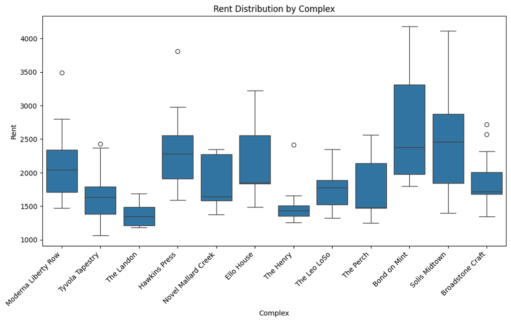

```python
# Boxplot by Complex
plt.figure(figsize=(12,6))
sns.boxplot(x='Complex', y='Rent', data=apt)
plt.xticks(rotation=45, ha='right')
plt.title('Rent Distribution by Complex')
plt.show()
```

This visualization highlights how rents are distributed across apartment complexes in Charlotte. Rather than focusing on technical mechanics, the emphasis here is on what the distribution patterns imply about market segmentation, pricing strategy, and renter experience.

Rents vary significantly between complexes. Some buildings, like The Landon and The Henry, show tightly clustered values, indicating consistent pricing. Others, such as Bond on Mint and Solis Midtown, display wide spreads, suggesting a broader mix of unit types and pricing tiers. This variability confirms that Charlotte’s rental market is not uniform. Different complexes are clearly targeting different renter segments.

Lower-rent complexes, including The Landon and The Henry, show lower medians and narrower distributions. These properties cater to more affordable housing needs. Mid-range buildings like Tyvola Tapestry, Novel Mallard Creek, and The Leo LoSo fall between approximately $\$1,500$ and $\$2,000$, offering moderate pricing with some variability. High-end complexes such as Bond on Mint, Solis Midtown, and Hawkins Press show higher medians, often above $\$2,300$, and wider distributions, reflecting upscale positioning and the presence of premium units.

Complexes with tight boxes and short whiskers, like The Landon and The Henry, offer stable and predictable pricing. This consistency may appeal to price-sensitive renters and simplify revenue forecasting. Complexes with wider boxes and whiskers, such as Bond on Mint and Solis Midtown, show greater variability. This could reflect a mix of unit sizes, amenity levels, or active pricing strategies.

The market appears segmented into three tiers: affordable, mid-range, and luxury. Complexes with wide variability often have greater pricing flexibility and potential for premium margins. Those with narrow ranges tend to compete more directly on affordability and consistency.

For renters, the distribution highlights where price certainty or diversity exists. For investors and property managers, it signals which buildings offer opportunities to serve multiple demographics versus those that prioritize stability.

## How Rent Changes with Bedroom Count

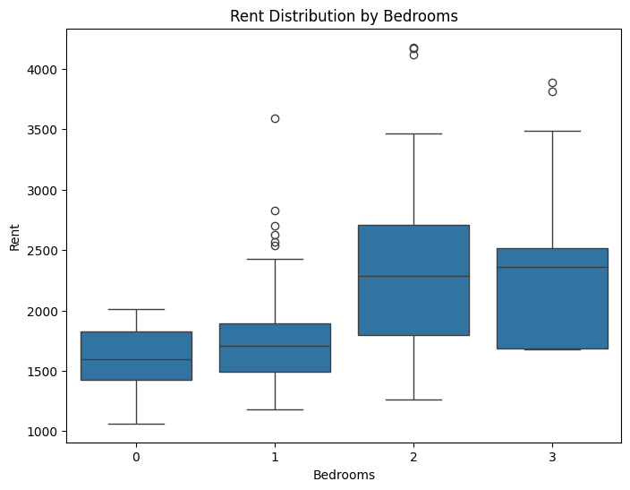

```python
# Boxplot by Bedrooms
plt.figure(figsize=(8,6))
sns.boxplot(x='Bedrooms', y='Rent', data=apt)
plt.title('Rent Distribution by Bedrooms')
plt.show()
```

This visualization tells a broader story about how rent behaves as bedroom count increases. Rather than focusing on how to read a boxplot, the emphasis here is on what the distribution patterns reveal about pricing structure and market segmentation.

Rents generally increase with the number of bedrooms. Studios have the lowest median rents, followed by one-bedroom units, then two- and three-bedroom units. This confirms the expected market structure where more space typically commands higher rent.

Studios show a tight distribution with relatively low variance. This suggests the studio market is well-defined with limited differentiation across complexes. One-bedroom units have a slightly wider spread but remain fairly consistent, indicating stable pricing and moderate variability.

Two-bedroom units display noticeably wider boxes and whiskers, reflecting greater variability in rent. This likely stems from differences in unit size, amenity levels, or location across complexes. Three-bedroom units have high medians and wide variability. Some overlap in pricing with two-bedroom units suggests market segmentation where some three-bedroom units are positioned as luxury offerings and others as standard family housing.

Lower-bedroom units, including studios and one-bedrooms, tend to be more consistent and competitive. These units likely appeal to students, singles, or young professionals. Pricing is less flexible because the market is saturated with similar offerings. Higher-bedroom units, such as two- and three-bedrooms, show more variable pricing. This suggests a less standardized market where landlords can charge premiums based on quality, square footage, or neighborhood. These units offer greater opportunity but also more uncertainty for renters.

The overlap between two- and three-bedroom rents reinforces that size alone does not determine price. Complex-level factors such as amenities, finishes, and location play a significant role in shaping rent.

## What the Boxplot Reveals About Neighborhood Pricing

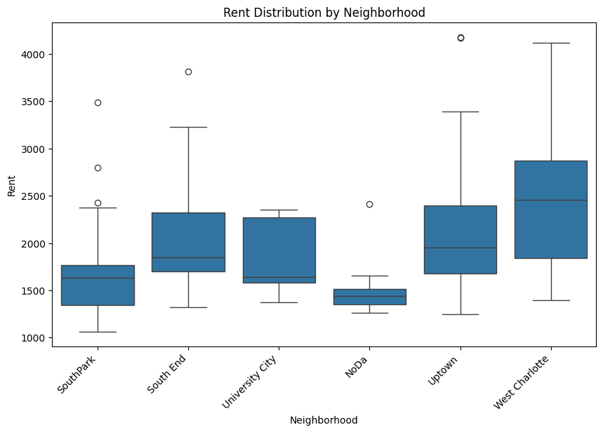

```python
# Boxplot by Neighborhood
plt.figure(figsize=(10,6))
sns.boxplot(x='Neighborhood', y='Rent', data=apt)
plt.xticks(rotation=45, ha='right')
plt.title('Rent Distribution by Neighborhood')
plt.show()
```

This visualization tells a broader story about how rents behave across Charlotte’s neighborhoods. Rather than simply noting which areas are more expensive, the focus here is on how distribution and variability reflect market segmentation, pricing strategy, and renter experience.

Tight ranges in SouthPark and NoDa indicate stable, uniform markets. Landlords in these areas likely operate within narrow pricing bands, with limited room to deviate from prevailing rates. Wide ranges in Uptown, West Charlotte, and South End suggest segmented markets. Luxury units, premium amenities, and varied property types contribute to broader spreads. This reflects more flexibility for landlords and more uncertainty for renters.

SouthPark and NoDa offer affordability and predictability. These markets attract cost-sensitive renters who prioritize stability. University City and South End show mid-range pricing with variability, allowing landlords to respond to demand and accommodate a wider range of renters. Uptown and West Charlotte feature premium pricing and broad variability, positioning them as competitive neighborhoods with tiered offerings. Landlords in these areas can capture diverse renter profiles but may face greater exposure to market shifts.

## Overall Insights on Rent Distributions and Varability

Charlotte’s rental market is defined by segmentation, diversity, and strategic layering. Across neighborhoods, bedroom types, and individual complexes, rent distributions reveal a clear tiered structure ranging from predictable, budget-friendly offerings to high-variability, premium-priced units.

Affordable areas like SouthPark and NoDa, as well as smaller units such as studios and one-bedrooms, show tight distributions and consistent pricing. These segments cater to cost-sensitive renters and offer stability for both tenants and investors. In contrast, neighborhoods like Uptown and West Charlotte, and larger units such as two- and three-bedrooms, exhibit broader spreads and higher variability. These segments reflect a mix of standard and luxury offerings with greater pricing flexibility and potential for premium margins.

Complex-level analysis reinforces this pattern. Properties with narrow rent ranges and low variability signal uniform layouts and targeted pricing strategies. Complexes with wider spreads and higher coefficients of variation suggest diverse unit mixes and broader market reach. The interquartile range further sharpens this view by focusing on the middle 50 percent of rents, offering a robust measure of typical pricing while minimizing the influence of outliers.

# Price per Square Foot Analysis

```python
# Make sure both columns exist
apt['price_per_sqft'] = apt['Rent'] / apt['Sqft']
```

## What Price Per Square Foot Reveals About Market Strategy

```python
pps_summary = apt.groupby(['Complex', 'Neighborhood']).agg(
    mean_rent=('Rent', 'mean'),
    mean_sqft=('Sqft', 'mean'),
    mean_ppsf=('price_per_sqft', 'mean'),
    median_ppsf=('price_per_sqft', 'median'),
    count=('Rent', 'size')
).reset_index()

pps_summary
```

|  | Complex | Neighborhood | mean_rent | mean_sqft | mean_ppsf | median_ppsf | count |
| --- | --- | --- | --- | --- | --- | --- | --- |
| 0 | Bond on Mint | Uptown | 2619.086957 | 880.891304 | 3.030273 | 3.023529 | 23 |
| 1 | Broadstone Craft | Uptown | 1856.945455 | 821.954545 | 2.309395 | 2.325281 | 22 |
| 2 | Ello House | South End | 2083.564008 | 864.205128 | 2.448893 | 2.421171 | 39 |
| 3 | Hawkins Press | South End | 2322.000000 | 830.111111 | 2.813044 | 2.823470 | 18 |
| 4 | Moderna Liberty Row | SouthPark | 2089.925926 | 1082.888889 | 1.955700 | 1.933426 | 18 |
| 5 | Novel Mallard Creek | University City | 1869.533333 | 890.000000 | 2.136937 | 2.097187 | 15 |
| 6 | Solis Midtown | West Charlotte | 2509.750000 | 894.000000 | 2.823031 | 2.802343 | 20 |
| 7 | The Henry | NoDa | 1515.000000 | 825.454545 | 1.871980 | 1.920949 | 11 |
| 8 | The Landon | SouthPark | 1381.153846 | 1070.384615 | 1.323852 | 1.299020 | 26 |
| 9 | The Leo LoSo | South End | 1753.846154 | 990.615385 | 1.850992 | 1.715949 | 26 |
| 10 | The Perch | Uptown | 1807.083333 | 876.833333 | 2.176058 | 1.978555 | 18 |
| 11 | Tyvola Tapestry | SouthPark | 1692.777778 | 872.111111 | 2.039358 | 2.108067 | 9 |

Normalizing rent by square footage offers one of the clearest views into how apartment complexes position themselves in Charlotte’s rental market. Price per square foot (PPSF) highlights whether properties prioritize luxury, space, or value, and how location influences those choices.

The Landon stands out for its low PPSF and large average unit size of 1,070 square feet. This suggests a strategy aimed at renters who value square footage, such as families, roommates, or remote workers. Bond on Mint and Solis Midtown take the opposite approach, offering smaller units around 880 to 894 square feet but commanding high PPSF. These properties emphasize lifestyle convenience and luxury over raw space.

- Premium Urban (2.50 to 3.00 PPSF): Small units, luxury amenities, central locations
- Mid-Market (2.00 to 2.40 PPSF): Moderate unit sizes, balanced pricing, good locations
- Value Market (below 2.00 PPSF): Larger units, lower PPSF, space-driven appeal

## What the Scatter Plot Reveals About PPSF and Market Dynamics

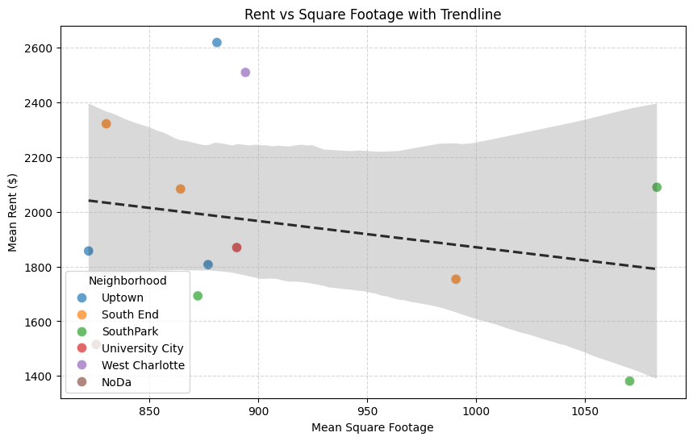

```python
plt.figure(figsize=(10,6))

sns.scatterplot(
    data=pps_summary,
    x="mean_sqft",
    y="mean_rent",
    hue="Neighborhood",
    s=80,
    alpha=0.7
)

# Add regression (trendline) across all complexes
sns.regplot(
    data=pps_summary,
    x="mean_sqft",
    y="mean_rent",
    scatter=False,
    color="black",
    line_kws={"linestyle":"--", "alpha":0.8}
)

plt.xlabel("Mean Square Footage")
plt.ylabel("Mean Rent ($)")
plt.title("Rent vs Square Footage with Trendline")
plt.legend(title="Neighborhood")
plt.grid(True, linestyle="--", alpha=0.5)
plt.show()
```

The trendline slopes downward, indicating a negative correlation between square footage and rent. As unit size increases, rent tends to decrease. While this may seem counterintuitive, it aligns with PPSF logic. Smaller units often command higher PPSF because they concentrate premium features into compact spaces. Larger units may offer more square footage but at a discounted rate per square foot.

The chart also highlights that renters are not just paying for space. They are paying for experience. Rent does not scale linearly with square footage. In high-demand urban areas, lifestyle and location drive pricing more than unit size.

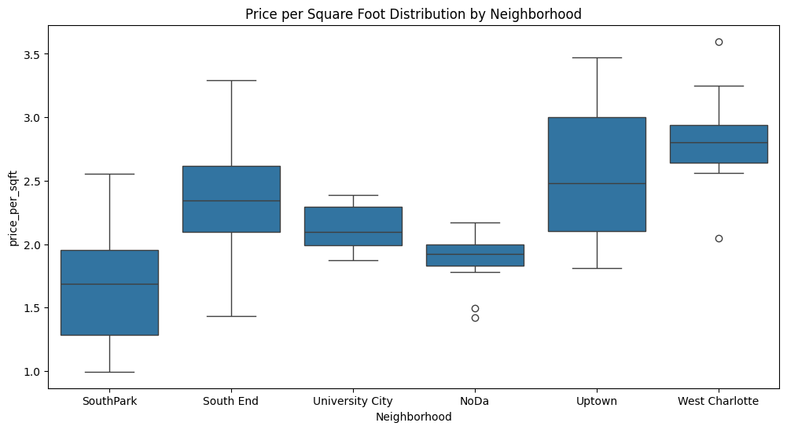

```python
plt.figure(figsize=(12,6))
sns.boxplot(data=apt, x='Neighborhood', y='price_per_sqft')
plt.title("Price per Square Foot Distribution by Neighborhood")
plt.show()
```

South End shows a moderate median PPSF but a wide IQR, indicating a neighborhood in transition. The variability suggests ongoing redevelopment or gentrification. Buyers may encounter both uncertainty and opportunity, with some properties priced like NoDa and others approaching Uptown levels.

West Charlotte stands out with a surprisingly high median PPSF. This may reflect recent investment, new developments, or rising demand. It signals a neighborhood undergoing change and warrants close attention.

## Overall Insights on Price Per Square Foot

The distribution of price per square foot (PPSF) confirms a segmented rental market across Charlotte. Uptown and South End are positioned as volatile and high-priced zones, while NoDa and University City offer greater stability and affordability. Wide interquartile ranges in Uptown and South End suggest potential for both elevated returns and increased risk. Narrow ranges in NoDa and SouthPark imply steadier performance and more predictable pricing.

For developers and investors, this segmentation presents opportunities for strategic positioning. Neighborhoods offering larger units at lower PPSF may be suitable for renovation, repositioning, or targeting remote workers and families seeking space-driven value. Pricing strategy is highly localized. The same square footage can command very different rents depending on the neighborhood, reinforcing the importance of context-specific pricing and market awareness.

This dynamic helps explain why Charlotte attracts both high-income renters seeking convenience and budget-conscious renters seeking space. PPSF reveals how properties compete, with some maximizing revenue per square foot and others offering more room at a lower relative price. It also highlights the influence of neighborhood context, confirming that the city’s rental market supports both luxury-driven and space-driven demand segments.

# Amenities Insights

```python
# Split the 'Amenities' column into lists
apt['Amenities_List'] = apt['Amenities'].fillna('').apply(lambda x: [a.strip().lower() for a in x.split(';') if a.strip()])

# 1. Total number of amenities per unit
apt['Total_Amenities'] = apt['Amenities_List'].apply(len)

# 2. Proportion of units with certain key amenities (example: pool, gym, parking, pet-friendly)
key_amenities = {
    'pool': ['pool'],
    'gym': ['gym', 'fitness'],
    'parking': ['parking'],
    'pet_friendly': ['pet-friendly', 'pet friendly', 'pet spa']
}

# Create binary columns for each key amenity using substring match
for col_name, keywords in key_amenities.items():
    apt[col_name] = apt['Amenities_List'].apply(lambda x: 1 if any(any(keyword in a for keyword in keywords) for a in x) else 0)

# Aggregate by complex
complex_amenities = apt.groupby('Complex').agg(
    Total_Units=('Unit_Variant', 'count'),
    Mean_Total_Amenities=('Total_Amenities', 'mean'),
    Pool_Proportion=('pool', 'mean'),
    Gym_Proportion=('gym', 'mean'),
    Parking_Proportion=('parking', 'mean'),
    Pet_Friendly_Proportion=('pet_friendly', 'mean')
).reset_index()

# 3. Amenity diversity: count of unique amenities across units in a complex
#complex_amenities['Amenity_Diversity'] = apt.groupby('Complex')['Amenities_List'].apply(
 #   lambda lists: len(set(a for sublist in lists for a in sublist))
#).values

# Display results
complex_amenities
```

|  | Complex | Total_Units | Mean_Total_Amenities | Pool_Proportion | Gym_Proportion | Parking_Proportion | Pet_Friendly_Proportion |
| --- | --- | --- | --- | --- | --- | --- | --- |
| 0 | Bond on Mint | 23 | 13.0 | 1.0 | 1.0 | 0.0 | 0.0 |
| 1 | Broadstone Craft | 22 | 13.0 | 1.0 | 1.0 | 0.0 | 0.0 |
| 2 | Ello House | 39 | 14.0 | 1.0 | 1.0 | 0.0 | 1.0 |
| 3 | Hawkins Press | 18 | 14.0 | 1.0 | 1.0 | 0.0 | 1.0 |
| 4 | Moderna Liberty Row | 18 | 13.0 | 1.0 | 1.0 | 0.0 | 1.0 |
| 5 | Novel Mallard Creek | 15 | 15.0 | 1.0 | 1.0 | 1.0 | 1.0 |
| 6 | Solis Midtown | 20 | 14.0 | 1.0 | 1.0 | 0.0 | 1.0 |
| 7 | The Henry | 11 | 14.0 | 1.0 | 1.0 | 0.0 | 1.0 |
| 8 | The Landon | 26 | 12.0 | 1.0 | 1.0 | 1.0 | 1.0 |
| 9 | The Leo LoSo | 26 | 12.0 | 1.0 | 1.0 | 0.0 | 1.0 |
| 10 | The Perch | 18 | 10.0 | 1.0 | 1.0 | 0.0 | 1.0 |
| 11 | Tyvola Tapestry | 9 | 12.0 | 1.0 | 1.0 | 1.0 | 1.0 |

Beyond rent and square footage, amenity offerings provide a deeper lens into how apartment complexes differentiate themselves in Charlotte’s rental market. The data highlights both baseline expectations and strategic segmentation.

Pools and fitness centers are offered by every complex in the dataset, indicating that these amenities have become standard. Renters expect them, and they no longer serve as differentiators. Instead, they represent the minimum threshold for competitive participation in the market.

Secondary amenities such as pet-friendliness and parking access show meaningful variation. Complexes like Bond on Mint and Broadstone Craft do not allow pets, suggesting a focus on urban professional renters who may prefer quieter environments or lower maintenance. In contrast, Novel Mallard Creek, The Landon, and Tyvola Tapestry are fully pet-friendly, likely targeting families, long-term tenants, or renters who value lifestyle flexibility.

Parking access also reflects strategic positioning. Only Novel Mallard Creek, The Landon, and Tyvola Tapestry include parking, aligning with suburban contexts where car ownership is more common. Inner-city complexes in South End and Uptown do not emphasize parking, signaling that tenants in these areas prioritize location and may rely more on walkability or public transit.

Amenity package density varies across properties. The Perch offers the fewest amenities at 10, while Novel Mallard Creek leads with 15. Higher-amenity complexes such as Novel Mallard Creek, Hawkins Press, and Ello House position themselves as premium lifestyle communities, offering more on-site experiences. The Perch likely represents a more budget-conscious or minimalist option, competing on price or location rather than features.

Charlotte’s rental market is competitive. Developers recognize that pools and gyms are expected, so true differentiation comes from niche amenities such as pet policies, parking, package services, and coworking spaces. The data suggests two dominant strategies:

Urban Lifestyle Premium: Smaller units, luxury branding, limited parking, and restricted pet policies. These properties appeal to high-income professionals. Suburban Lifestyle Value: Larger units, included parking, pet-friendly policies, and higher amenity counts. These properties attract families and long-term residents.

Overall, the data shows that while some amenities are standard, others serve as strategic tools for segmentation. Complexes with extensive amenity packages target renters seeking a full-service lifestyle, while leaner offerings compete on affordability or location. This reinforces the importance of aligning amenity strategy with renter priorities and neighborhood context.

# Unit Size Insights

## What Bedroom-Normalized Unit Size Reveals About Market Strategy

```python
# --- 1. Flag studios ---
apt['Is_Studio'] = apt['Bedrooms'].astype(str).eq('Studio')

# --- 2. Convert numeric bedrooms ---
apt['Bedrooms_Numeric'] = pd.to_numeric(apt['Bedrooms'], errors='coerce')

# --- 3. Replace 0 bedrooms with NaN to avoid division by zero ---
apt.loc[apt['Bedrooms_Numeric'] == 0, 'Bedrooms_Numeric'] = np.nan

# --- 4. Compute Sqft per Bedroom for numeric bedrooms ---
apt['Sqft_per_Bedroom'] = apt['Sqft'] / apt['Bedrooms_Numeric']

# --- 5. Create a separate column for studio sqft ---
apt['Studio_Sqft'] = np.where(apt['Is_Studio'], apt['Sqft'], np.nan)

# --- 6. Separate numeric bedrooms and studios ---
numeric_units = apt[~apt['Bedrooms_Numeric'].isna()]
studio_units = apt[apt['Is_Studio']]

# --- 7. Aggregate numeric bedrooms ---
numeric_stats = numeric_units.groupby(['Complex', 'Bedrooms']).agg(
    Mean_Sqft_per_Bedroom=('Sqft_per_Bedroom', 'mean'),
    Median_Sqft_per_Bedroom=('Sqft_per_Bedroom', 'median'),
    Min_Sqft_per_Bedroom=('Sqft_per_Bedroom', 'min'),
    Max_Sqft_per_Bedroom=('Sqft_per_Bedroom', 'max'),
    Std_Sqft_per_Bedroom=('Sqft_per_Bedroom', 'std')
).reset_index()

# --- 8. Aggregate studios as separate rows ---
studio_stats = studio_units.groupby('Complex').agg(
    Mean_Sqft_per_Bedroom=('Studio_Sqft', 'mean')
).reset_index()
studio_stats['Bedrooms'] = 'Studio'
studio_stats['Median_Sqft_per_Bedroom'] = studio_stats['Mean_Sqft_per_Bedroom']
studio_stats['Min_Sqft_per_Bedroom'] = studio_stats['Mean_Sqft_per_Bedroom']
studio_stats['Max_Sqft_per_Bedroom'] = studio_stats['Mean_Sqft_per_Bedroom']
studio_stats['Std_Sqft_per_Bedroom'] = np.nan

# --- 9. Combine numeric and studio stats ---
unit_size_stats = pd.concat([numeric_stats, studio_stats], ignore_index=True)
unit_size_stats.sort_values(['Complex', 'Bedrooms'], inplace=True)
unit_size_stats.reset_index(drop=True, inplace=True)

unit_size_stats
```

|  | Complex | Bedrooms | Mean_Sqft_per_Bedroom | Median_Sqft_per_Bedroom | Min_Sqft_per_Bedroom | Max_Sqft_per_Bedroom | Std_Sqft_per_Bedroom |
| --- | --- | --- | --- | --- | --- | --- | --- |
| 0 | Bond on Mint | 1 | 740.0 | 746.0 | 659.0 | 801.0 | 52.089666 |
| 1 | Bond on Mint | 2 | 602.861111 | 557.5 | 541.5 | 764.5 | 89.498177 |
| 2 | Broadstone Craft | 1 | 697.785714 | 670.0 | 560.0 | 895.0 | 96.505224 |
| 3 | Broadstone Craft | 2 | 551.714286 | 556.5 | 479.0 | 620.0 | 53.09022 |
| 4 | Ello House | 1 | 742.0 | 746.0 | 558.0 | 989.0 | 98.623114 |
| 5 | Ello House | 2 | 587.636364 | 573.0 | 527.5 | 714.5 | 50.558922 |
| 6 | Hawkins Press | 1 | 774.6 | 830.5 | 582.0 | 861.0 | 104.010897 |
| 7 | Hawkins Press | 2 | 518.75 | 541.75 | 438.5 | 553.0 | 54.003858 |
| 8 | Hawkins Press | 3 | 449.333333 | 449.333333 | 449.333333 | 449.333333 | <NA> |
| 9 | Moderna Liberty Row | 1 | 912.625 | 881.5 | 747.0 | 1333.0 | 189.607819 |
| 10 | Moderna Liberty Row | 2 | 633.625 | 623.5 | 562.0 | 703.5 | 49.19041 |
| 11 | Moderna Liberty Row | 3 | 467.333333 | 467.333333 | 467.333333 | 467.333333 | <NA> |
| 12 | Novel Mallard Creek | 1 | 768.333333 | 735.0 | 689.0 | 980.0 | 113.164777 |
| 13 | Novel Mallard Creek | 2 | 571.666667 | 565.25 | 539.0 | 614.5 | 24.963306 |
| 14 | Solis Midtown | 1 | 802.888889 | 797.0 | 627.0 | 999.0 | 128.171218 |
| 15 | Solis Midtown | 2 | 585.416667 | 549.0 | 499.0 | 707.5 | 83.219239 |
| 16 | Solis Midtown | 3 | 478.333333 | 478.333333 | 478.333333 | 478.333333 | <NA> |
| 17 | The Henry | 1 | 723.857143 | 740.0 | 656.0 | 778.0 | 47.642518 |
| 18 | The Henry | 2 | 548.25 | 548.25 | 544.5 | 552.0 | 5.303301 |
| 19 | The Henry | 3 | 413.333333 | 413.333333 | 413.333333 | 413.333333 | <NA> |
| 20 | The Landon | 1 | 799.5 | 782.5 | 715.0 | 918.0 | 88.616348 |
| 21 | The Landon | 2 | 570.583333 | 554.25 | 496.0 | 676.0 | 69.00752 |
| 22 | The Landon | 3 | 430.0 | 432.333333 | 350.333333 | 500.333333 | 48.639719 |
| 23 | The Leo LoSo | 1 | 703.916667 | 724.0 | 531.0 | 807.0 | 91.124748 |
| 24 | The Leo LoSo | 2 | 595.590909 | 608.0 | 543.5 | 614.0 | 27.861998 |
| 25 | The Leo LoSo | 3 | 467.333333 | 467.333333 | 467.333333 | 467.333333 | 0.0 |
| 26 | The Perch | 1 | 639.375 | 668.0 | 459.0 | 789.0 | 120.175987 |
| 27 | The Perch | 2 | 543.4 | 520.5 | 493.0 | 617.0 | 54.698492 |
| 28 | The Perch | 3 | 458.444444 | 453.666667 | 449.666667 | 472.0 | 11.908603 |
| 29 | Tyvola Tapestry | 1 | 645.75 | 665.5 | 570.0 | 682.0 | 51.564684 |
| 30 | Tyvola Tapestry | 2 | 520.25 | 520.25 | 513.5 | 527.0 | 9.545942 |
| 31 | Tyvola Tapestry | 3 | 454.666667 | 454.666667 | 442.666667 | 466.666667 | 16.970563 |

Normalizing unit size by bedroom count offers a focused view of how much space renters receive per bedroom. This metric helps distinguish between luxury-oriented layouts and cost-efficient designs, revealing how complexes position themselves in Charlotte’s rental market.

The average square footage per bedroom highlights typical space allocation. Moderna Liberty Row and Solis Midtown offer 912 and 803 square feet per bedroom respectively, indicating spacious layouts that appeal to renters seeking comfort and premium living. In contrast, Hawkins Press and The Henry offer more compact configurations, with 519 and 413 square feet per bedroom. These units likely target renters who prioritize affordability over space.

Across all complexes, one-bedroom units tend to offer the most square footage per bedroom, while three-bedroom units offer the least. This reflects a common design tradeoff, where larger units balance cost efficiency with market pricing.

Standard deviation in square footage per bedroom reveals consistency or variability within unit types. Moderna Liberty Row’s one-bedroom units show a high standard deviation of 189 square feet, suggesting a range of layouts and contributing to flexible pricing. The Henry’s two-bedroom units show a low standard deviation of just 5 square feet, indicating a uniform product that supports consistent leasing and predictable revenue.

Complexes with higher square footage per bedroom typically appeal to lifestyle-focused renters. These properties often feature elevated PPSF rents, premium amenities, and smaller unit counts. Examples include Moderna Liberty Row, Solis Midtown, and Bond on Mint. Complexes with lower square footage per bedroom target budget-conscious renters, offering smaller but functional spaces. Examples include Hawkins Press, The Henry, and The Landon.

For investors, larger units with variable sizes allow for tiered pricing strategies, offering both premium and standard options within the same complex. Smaller, uniform units simplify management and support stable revenue models.

## What Square Footage per Bedroom Reveals About Spatial Design

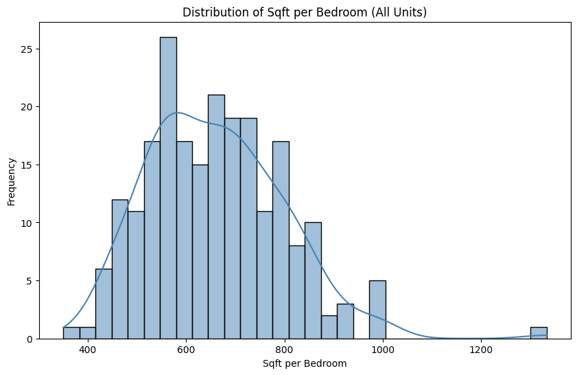

```python
# --- 3. Histogram of Sqft per Bedroom ---
plt.figure(figsize=(10,6))
sns.histplot(apt['Sqft_per_Bedroom'], bins=30, kde=True, color="steelblue")
plt.title("Distribution of Sqft per Bedroom (All Units)")
plt.xlabel("Sqft per Bedroom")
plt.ylabel("Frequency")
plt.show()
```

The distribution is right-skewed, with most units falling between 400 and 800 square feet per bedroom. This suggests that the bulk of Charlotte’s rental market is designed for efficient living, likely targeting affordability and density. Units offering significantly more space are rare and likely command premium pricing.

Peak density occurs around 600 square feet per bedroom. This clustering indicates a design sweet spot where developers balance comfort with cost. It reflects a standardized design philosophy that may be shaped by zoning regulations, construction economics, or renter expectations.

Units with more than 900 square feet per bedroom are uncommon. These are likely luxury homes or older builds with generous layouts. Their scarcity positions them as niche offerings rather than market norms.

## What Square Footage per Bedroom Reveals About Complex-Level Design

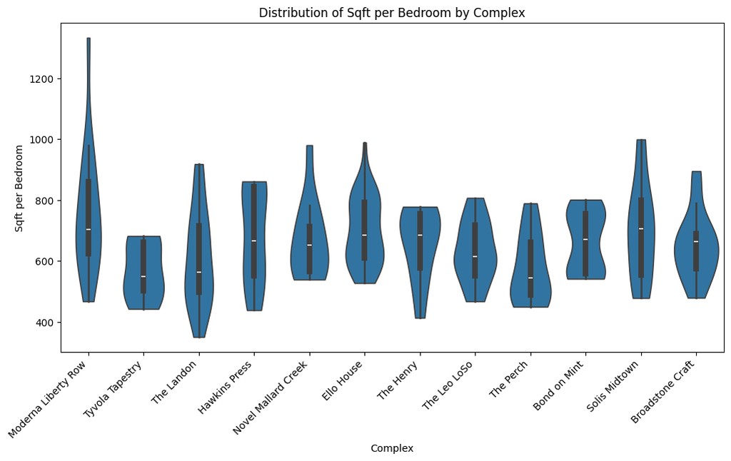

```python
# --- 4. Violin Plot by Complex ---
plt.figure(figsize=(12,6))
sns.violinplot(x="Complex", y="Sqft_per_Bedroom", data=apt, inner="box", cut=0)
plt.xticks(rotation=45, ha="right")
plt.title("Distribution of Sqft per Bedroom by Complex")
plt.xlabel("Complex")
plt.ylabel("Sqft per Bedroom")
plt.show()
```

Variation in median square footage per bedroom highlights differences in layout generosity. Complexes such as The Henry and Moderna Liberty Row show higher medians, suggesting more spacious designs. These properties likely represent premium or luxury offerings, catering to tenants who value comfort and space. They may be targeting professionals, families, or long-term renters.

Distribution width reveals consistency or diversity in unit design. Tight distributions, as seen in Toyota Tapestry and The Leo, indicate standardized floor plans and uniform layouts. These complexes may be optimized for efficiency and affordability, appealing to budget-conscious renters or students. Wide distributions, such as those in Solis Midtown and Broadstone Craft, suggest a mix of unit types with varying space allocations. These properties offer flexibility and may attract a broader demographic, including transitional renters or those seeking mixed-use environments.

The shape of each violin provides additional context. Bulging violins at lower square footage per bedroom values indicate a high density of compact units. This pattern reflects urban design principles or cost-saving strategies. Flatter violins with higher medians suggest less density and more generous layouts, often associated with suburban or upscale developments.

## What Rent vs. Square Footage per Bedroom Reveals About Neighborhood Value

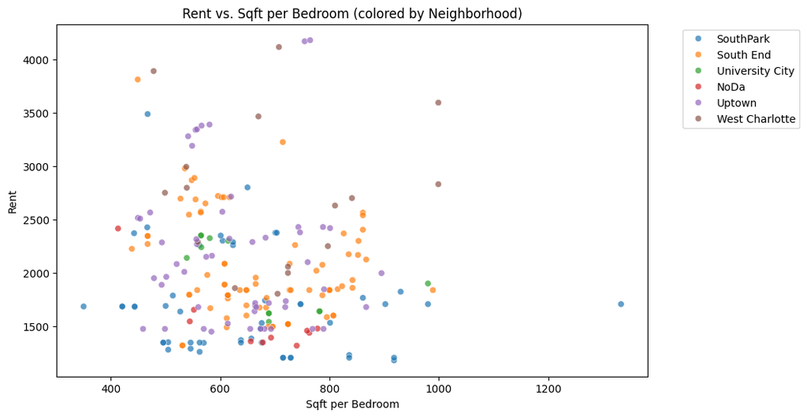

```python
# --- 5. Scatter Plot: Rent vs. Sqft per Bedroom ---
plt.figure(figsize=(10,6))
sns.scatterplot(x="Sqft_per_Bedroom", y="Rent", hue="Neighborhood", data=apt, alpha=0.7)
plt.title("Rent vs. Sqft per Bedroom (colored by Neighborhood)")
plt.xlabel("Sqft per Bedroom")
plt.ylabel("Rent")
plt.legend(bbox_to_anchor=(1.05, 1), loc='upper left')
plt.show()
```

Rent does not always scale with space. Neighborhoods such as Uptown and South End show high rents even for units with modest square footage per bedroom. These areas are pricing based on location, lifestyle, and demand rather than physical space. Renters are paying for proximity to amenities, nightlife, and prestige.

Clusters of value appear in neighborhoods like NoDa and University City, where units offer more square footage per bedroom at lower rent levels. These areas likely appeal to students, families, or budget-conscious renters. They may also reflect less speculative pricing and more stable demand.

West Charlotte presents mixed signals. Some units offer generous space at moderate rents, while others are more compact and priced higher. This pattern may indicate a transitional market, with new developments pushing prices upward while older stock continues to offer value.

SouthPark shows a balanced profile, offering moderate rent for moderate space. This suggests a more predictable and mature market, likely targeting long-term tenants who seek stability and quality without extremes.

## Overall Insights on Unit Size and Market Strategy

Unit size per bedroom serves as a proxy for livability, comfort, and design intent. Across Charlotte’s rental market, this metric reveals how developers balance space allocation with pricing, density, and tenant targeting.

One-bedroom units consistently offer the most square footage per bedroom, reflecting their role as premium or professional-oriented products. These units often appeal to single-occupant renters seeking comfort, privacy, and lifestyle amenities. In contrast, three-bedroom units offer the least space per bedroom, signaling a cost-efficiency strategy aimed at families or roommates willing to trade personal space for affordability.

Complexes with high square footage per bedroom tend to position themselves as lifestyle-driven communities. They often feature elevated PPSF rents, premium amenities, and flexible unit mixes. Complexes with lower square footage per bedroom prioritize efficiency and affordability, offering standardized layouts that support predictable leasing and operational simplicity.

Variability in unit size per bedroom reflects strategic diversity. High variability suggests an effort to appeal to multiple renter types within the same complex, while low variability indicates a uniform product designed for consistency and streamlined management.

Neighborhood context further shapes unit size strategy. Urban areas favor compact, functional layouts that support density and walkability. Suburban zones offer more generous space allocations, aligning with long-term tenants and family-oriented living. The clustering of unit sizes across properties suggests design uniformity, likely driven by zoning constraints, construction economics, and market expectations.

Ultimately, unit size per bedroom is not just a design choice. It is a reflection of market segmentation, renter priorities, and the trade-offs developers make between livability, density, and profitability.

# Outlier Detection

## What Z-Score Outlier Detection Reveals About Rent Extremes

```python
# Ensure apt has no duplicate index issues
apt_clean = apt.reset_index(drop=True)

# Compute z-scores for rent within each bedroom type
apt_clean['Rent_Z'] = apt_clean.groupby('Bedrooms')['Rent'].transform(
    lambda x: (x - x.mean()) / x.std()
)

# Flag outliers (commonly |z| > 3)
apt_clean['Outlier_Rent'] = apt_clean['Rent_Z'].abs() > 3

# Show only units flagged as outliers, sorted by z-score
rent_outliers = apt_clean[apt_clean['Outlier_Rent']].sort_values(by='Rent_Z', ascending=False)

# Display key columns for review
rent_outliers = rent_outliers[['Complex', 'Address', 'Unit_Variant', 'Bedrooms', 'Rent', 'Sqft', 'Rent_Z']]

# Output
rent_outliers
```

|  | Complex | Address | Unit_Variant | Bedrooms | Rent | Sqft | Rent_Z |
| --- | --- | --- | --- | --- | --- | --- | --- |
| 215 | Solis Midtown | 1133 Harding Pl, Charlotte, NC 28204 | A11-P | 1 | 3594.0 | 999.0 | 4.643876 |

This output reflects the use of z-scores to identify rent outliers across bedroom types, offering a more stringent alternative to the IQR method previously applied. By standardizing rent values relative to their mean and standard deviation, this approach isolates only the most extreme deviations.

For each bedroom type, rent values were converted into z-scores using the formula:

$$ z \space = \space \frac{\text{Rent} - \text{mean(Rent)}}{\text{std(Rent)}} $$

Apartments with absolute z-scores greater than 3 were flagged as outliers, indicating rents that are significantly higher or lower than the average for that bedroom category.

From an analytical perspective, this unit is exceptionally expensive relative to its peers and could distort average rent calculations if included. Z-score detection is particularly useful when the goal is to isolate extreme pricing behavior rather than moderate anomalies.

## What IQR-Based Outlier Detection Reveals About Rent Variability

```python
# Reset index to make sure 'Bedrooms' is only a column
apt_reset = apt.reset_index(drop=True)

# Function to flag outliers using IQR
def flag_outliers(group):
    Q1 = group['Rent'].quantile(0.25)
    Q3 = group['Rent'].quantile(0.75)
    IQR = Q3 - Q1
    lower_bound = Q1 - 1.5 * IQR
    upper_bound = Q3 + 1.5 * IQR
    group['Outlier_Rent'] = (group['Rent'] < lower_bound) | (group['Rent'] > upper_bound)
    return group

# Apply IQR outlier detection per bedroom type
apt_reset = apt_reset.groupby('Bedrooms', group_keys=False).apply(flag_outliers)

# Show only the flagged outliers
rent_outliers = apt_reset[apt_reset['Outlier_Rent']].sort_values(by='Rent', ascending=False)

# Display key columns
rent_outliers[['Complex', 'Address', 'Unit_Variant', 'Bedrooms', 'Rent', 'Sqft', 'Outlier_Rent']]
```

|  | Complex | Address | Unit_Variant | Bedrooms | Rent | Sqft | Outlier_Rent |
| --- | --- | --- | --- | --- | --- | --- | --- |
| 202 | Bond on Mint | 1007 S Mint St, Charlotte, NC 28203 | T2 | 2 | 4179.0 | 1529.0 | True |
| 201 | Bond on Mint | 1007 S Mint St, Charlotte, NC 28203 | T1 | 2 | 4169.0 | 1509.0 | True |
| 221 | Solis Midtown | 1133 Harding Pl, Charlotte, NC 28204 | C1 | 2 | 4115.0 | 1415.0 | True |
| 222 | Solis Midtown | 1133 Harding Pl, Charlotte, NC 28204 | C2 | 3 | 3890.0 | 1435.0 | True |
| 70 | Hawkins Press | 2200 Dunavant St, Charlotte, NC 28203 | C1A | 3 | 3811.0 | 1348.0 | True |
| 215 | Solis Midtown | 1133 Harding Pl, Charlotte, NC 28204 | A11-P | 1 | 3594.0 | 999.0 | True |
| 214 | Solis Midtown | 1133 Harding Pl, Charlotte, NC 28204 | A11 | 1 | 2830.0 | 999.0 | True |
| 213 | Solis Midtown | 1133 Harding Pl, Charlotte, NC 28204 | A10 | 1 | 2700.0 | 841.0 | True |
| 212 | Solis Midtown | 1133 Harding Pl, Charlotte, NC 28204 | A9 | 1 | 2630.0 | 810.0 | True |
| 63 | Hawkins Press | 2200 Dunavant St, Charlotte, NC 28203 | A25A-Den | 1 | 2564.0 | 861.0 | True |
| 64 | Hawkins Press | 2200 Dunavant St, Charlotte, NC 28203 | A26A-Den | 1 | 2539.0 | 861.0 | True |

This table summarizes the results of applying the interquartile range (IQR) method to identify rent outliers within Charlotte’s apartment dataset. By evaluating rents within each bedroom category, the analysis isolates units that deviate significantly from their direct peers.

High-rent outliers include apartments such as Bond on Mint two-bedroom units priced at $\$4,179$ and $\$4,169$, and select Solis Midtown units. These properties are significantly more expensive than typical rents for their bedroom type. They may represent luxury or premium offerings, including penthouses, newly renovated units, or apartments with elevated amenity packages.

Because the IQR method was applied within each bedroom type, the analysis captures outliers relative to their immediate category. For example, a $\$3,500$ three-bedroom unit may not be extreme across the full dataset, but it is flagged as high within the three-bedroom group. This approach ensures that comparisons are contextually accurate and sensitive to bedroom-specific pricing norms.

From an analytical standpoint, these outliers can distort average rent calculations if not handled separately. They highlight apartments that diverge meaningfully from the typical market, either through elevated pricing or unusually low rents. Depending on the analytical goal, these units may warrant separate investigation, exclusion from summary statistics, or targeted analysis to understand their unique characteristics.

## What Rent Distributions by Bedroom Type Reveals About Market Dymanics

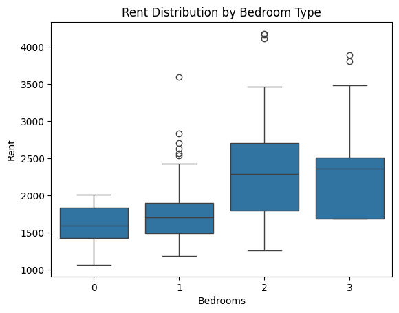

```python
sns.boxplot(data=apt, x='Bedrooms', y='Rent')
plt.title("Rent Distribution by Bedroom Type")
plt.show()
```

This box plot provides a concentrated view of rent variability across bedroom types, offering a valuable lens for outlier detection and pricing strategy. By examining the distribution and extremities, the plot uncovers structural patterns and market segmentation within Charlotte’s rental landscape.

Outliers appear most prominently in one, two, and three-bedroom units, with rents far above the upper whisker. These units are likely luxury offerings or newly renovated properties priced well above the norm. Their presence indicates that even within a bedroom category, a premium tier exists that is not captured by the median or interquartile range.

Studio units display a tight distribution with few outliers. This consistency suggests limited variation in layout and features, positioning studios as a highly commoditized segment. They are well-suited for short-term renters or urban dwellers seeking predictable pricing and compact living.

## Overall Insights on Outlier Detection

Outlier detection reveals the hidden dynamics of Charlotte’s rental market by identifying units that deviate meaningfully from their peers. These deviations often signal the presence of distinct submarkets, such as luxury inventory, budget offerings, or transitional properties.

The IQR method is effective for capturing broader variability. It flags units that are moderately or significantly different from the norm, helping analysts understand the full spread of pricing within each bedroom category. This method is especially useful for identifying affordability anchors and speculative pricing across a wide range of units.

The z-score method is more selective. It isolates only the most extreme cases—units that are several standard deviations away from the mean. This approach is ideal for pinpointing statistical outliers that may distort averages or represent niche pricing strategies. It offers a sharper lens into pricing extremes and is well-suited for identifying units that warrant separate treatment in analysis.

Together, these methods provide complementary perspectives. IQR highlights the breadth of market variability, while z-scores focus on the most pronounced deviations. Their combined use supports more accurate segmentation, pricing strategy evaluation, and identification of atypical inventory.

Ultimately, outlier detection enhances analytical precision. It helps clarify which units are representative of the broader market and which are exceptions. This distinction is critical for drawing valid conclusions, informing stakeholder decisions, and tailoring recommendations to different renter profiles and investment strategies.

# Correlations

## What the Correlation Heatmap Reveals About Housing Relationships

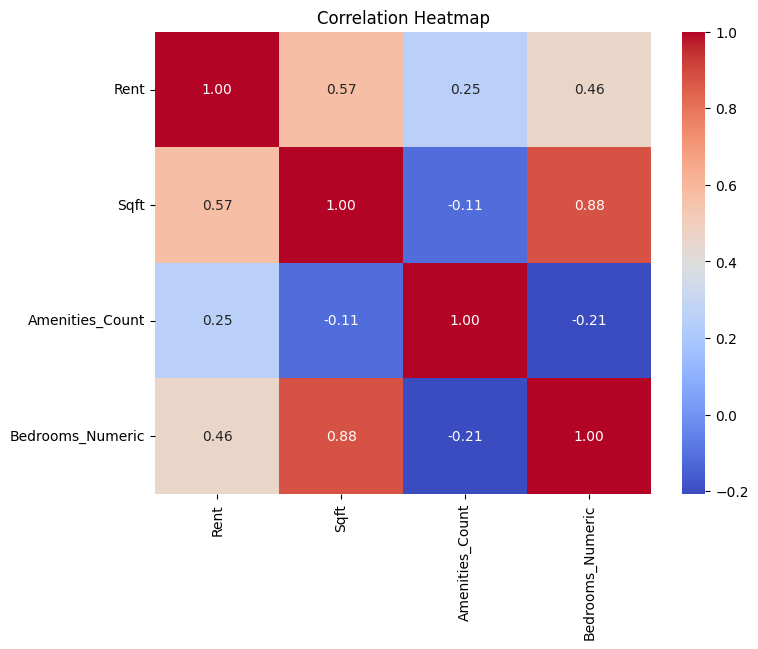

```python
# --- 1. Create numeric features if not already ---
apt_reset = apt.reset_index(drop=True)

# Count of amenities per unit
apt_reset['Amenities_Count'] = apt_reset['Amenities'].str.count(';') + 1  # assuming ';' separates amenities

# Ensure Bedrooms numeric
apt_reset['Bedrooms_Numeric'] = pd.to_numeric(apt_reset['Bedrooms'], errors='coerce')

# --- 2. Select numeric columns for correlation ---
corr_cols = ['Rent', 'Sqft', 'Amenities_Count', 'Bedrooms_Numeric']
corr_df = apt_reset[corr_cols]

# --- 3. Compute correlation matrix ---
corr_matrix = corr_df.corr()

# --- 4. Plot heatmap ---
plt.figure(figsize=(8,6))
sns.heatmap(corr_matrix, annot=True, cmap='coolwarm', fmt=".2f")
plt.title('Correlation Heatmap')
plt.show()
```

Square footage and bedroom count show a very strong correlation (0.88), reflecting standardized design logic. Developers typically scale unit size with bedroom count, resulting in a predictable and formulaic relationship that simplifies modeling but limits flexibility.

Square footage and amenities count show a slight negative correlation (-0.11), hinting that larger units may have fewer amenities. This could reflect older or suburban properties that prioritize private space over shared features, suggesting a trade-off between interior size and communal perks.

Bedroom count and amenities count show a slightly stronger negative correlation (-0.21), indicating that units with more bedrooms tend to have fewer amenities. This may reflect design choices for family-oriented or long-term tenants who value space over luxury features. Smaller units may be located in high-end buildings with more shared amenities.

## What Per-Bedroom Correlation Heatmaps Reveal About Rent Drivers

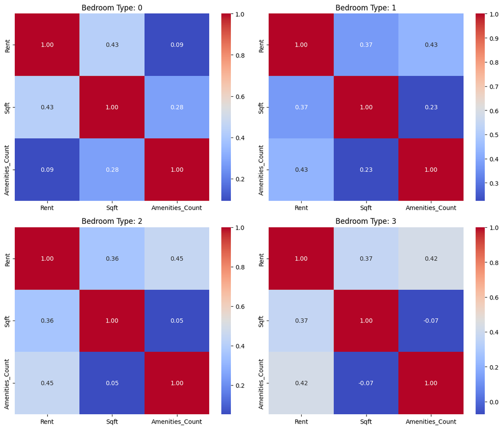

```python
# Get all unique bedroom types
bedroom_types = apt_reset['Bedrooms'].unique()

# Determine grid size
n = len(bedroom_types)
cols = 2  # adjust number of columns per row
rows = math.ceil(n / cols)

# Create subplots
fig, axes = plt.subplots(rows, cols, figsize=(cols*6, rows*5))
axes = axes.flatten()  # flatten in case of 1 row

for i, b in enumerate(bedroom_types):
    subset = apt_reset[apt_reset['Bedrooms'] == b]

    corr_cols_b = ['Rent', 'Sqft', 'Amenities_Count']

    # Skip if less than 2 rows
    if subset[corr_cols_b].dropna().shape[0] < 2:
        continue

    corr_matrix_b = subset[corr_cols_b].corr()

    sns.heatmap(corr_matrix_b, annot=True, cmap='coolwarm', fmt=".2f", ax=axes[i])
    axes[i].set_title(f'Bedroom Type: {b}')

# Turn off any empty subplots
for j in range(i+1, len(axes)):
    axes[j].axis('off')

plt.tight_layout()
plt.show()
```

This set of correlation heatmaps, segmented by bedroom count, offers a focused view of how rent, square footage, and amenity count interact across unit types. By isolating relationships within each bedroom category, the analysis highlights how pricing logic and design priorities shift across renter segments.

For studio units (bedroom type 0), rent shows a moderate correlation with square footage (0.43) and a weak correlation with amenities (0.09). This suggests that even small variations in size influence pricing, while amenities play a minimal role. Studios appear to follow a compact, standardized pricing model.

## Overall Insights on Correlation Patterns in Rental Housing Data

Correlation analysis helps quantify how housing variables move together, but its deeper utility is in revealing design logic, pricing strategy, and consumer segmentation. In Charlotte’s rental market, these relationships are not uniform. They shift meaningfully across bedroom types and reflect broader market dynamics.

Square footage generally correlates positively with rent, confirming that larger units tend to cost more. However, the strength of this relationship varies by bedroom count, indicating that size alone does not dictate pricing. This variability suggests that other factors such as location, layout, and amenities modulate the value of space differently across renter segments.

The strong correlation between square footage and bedroom count reflects design uniformity. Developers tend to scale unit size predictably with bedroom count, creating a formulaic relationship that simplifies construction and modeling. However, this uniformity may limit flexibility and innovation in unit design.

Overall, correlation analysis reveals that rent is shaped by multiple interdependent variables. It confirms that no single factor fully explains pricing, and that the market incorporates both tangible attributes and intangible value drivers. By segmenting correlations by bedroom type, analysts can uncover nuanced patterns that support more accurate modeling, targeted design strategies, and refined market positioning.

# What Descriptive Statistics Reveal About Charlotte's Rental Market

Descriptive statistics across Charlotte’s rental dataset confirm a market shaped by segmentation, variability, and strategic layering. Measures of central tendency, dispersion, and correlation collectively illustrate how rent behavior responds to spatial context, unit configuration, and renter priorities.

Rent distributions by neighborhood reveal clear geographic stratification. Uptown and West Charlotte show elevated medians and wider interquartile ranges, indicating premium pricing and volatility. SouthPark and NoDa display lower medians and tighter spreads, reflecting affordability and pricing stability. These patterns confirm the presence of distinct submarkets with localized pricing logic.

Price per square foot (PPSF) reinforces unit-level segmentation. Studios and one-bedroom units command higher PPSF values, especially in central locations, suggesting a premium on compact urban living. Larger units offer more space but exhibit greater variance, highlighting trade-offs between square footage and affordability. These trends align with observed differences in standard deviation and coefficient of variation across bedroom types.

Complex-level variability is evident in rent range analysis and IQR comparisons. Properties with narrow distributions reflect standardized layouts and targeted pricing strategies. Complexes with broader spreads and higher variability suggest diverse unit mixes and flexible positioning. These measures highlight how developers tailor offerings to multiple renter personas within the same property.

Unit size per bedroom reveals design intent and livability trade-offs. One-bedroom units consistently offer the highest square footage per bedroom, while three-bedroom units offer the least. This inverse relationship reflects cost-efficiency strategies and segmentation by tenant type. Variability in this metric across complexes supports the presence of differentiated design approaches.

Correlation analysis quantifies structural relationships between key variables. Rent correlates moderately with square footage and bedroom count, though the strength of these relationships varies by unit type. Amenities show weak to moderate correlations, especially in larger units, suggesting that lifestyle features influence pricing but are not primary drivers. These findings underscore the multifactorial nature of rent and the importance of segment-specific modeling.

Overall, the descriptive statistics reveal a rental market that is both diverse and strategically organized. Charlotte’s housing landscape accommodates a wide range of renter preferences, from affordability to luxury, and from compact urban units to spacious suburban homes. For analysts, developers, and investors, this statistical clarity supports more accurate forecasting, targeted design, and context-aware pricing strategies.

As we move forward, geospatial analysis will offer a powerful lens into how location influences rent behavior across Charlotte. By mapping pricing patterns, unit density, and amenity distribution, we can uncover spatial trends that complement our statistical findings. Stay tuned as we explore how geography shapes market segmentation, investment strategy, and renter experience across the city.